# Analysis of the Housing Crisis

**by Timothy Brimmer**

#### Importance of the Housing Market :

The housing market is vital to the US stock exchange and in turn the world. Every person needs a home to live in and therefore the housing market is one of if not the most important market on wall street. When the Market goes up everything is great, and when it crashes.... the world changes. We saw an event like this happen in 2008, when the housing market collapsed due to unsafe loans and uncollected debts. This event changed how Americans thought about the housing market and made many forever skeptical about this "concrete market" ([FiveThirtyEight](https://fivethirtyeight.com/features/its-not-just-silicon-valley-bank-americans-havent-trusted-banks-for-years/)). This event sent shockwaves throughout the US with millions of Americans losing their homes. It sent a shiver down the spine of any who lived through the great depression and reminded everyone that nothing within the stock exchange is full proof, and that everything needs some oversight so we never get put back into a position like in 2008. That being said, the housing market is only as great as the people who buy the houses, if no one is buying houses, the market will drop, if people are buying a lot, the market will shoot up until its at the point where people can't afford, and then it will drop again to normal levels where average people can buy homes.... or at least, that is how its supposed to work.

#### Why you should care :

As stated before everyone in the world needs a home, whether that home is rented or owned doesn't matter too much, although long term renting only benefits one person : The owner of the building. By renting or subleasing you hold almost no bargaining power and can be kicked out as soon as your lease is up without an option to release. The owner has all the power, he has the equity of the house and decides what the rent will actually be. After years of renting you still have no assets and have spent thousands of dollars. This is the benefit of buying a house or building your own house, and with every new graduating class of college students, you have another generation of people that enter the home market. That is why you should care, because this market affects everyone, and not being able to buy a home gives even more power to the land/property owners and they realize you can't go anywhere else and can raise rent as high as they want.

#### Purpose :

So we know what's on the line, so what? If the market is going up we have a strong economy and people can afford houses, and if it goes down its just a correction. Well not exactly, the past few years housing prices throughout the US have been growing increasingly with many complaining about not being able to even buy homes anymore. This then raises the question, if people can't afford these houses, how is the market still going up? There could be many contributors to this very strange market we see that I will look into. Some of these factors include : Inflation rates, Population Growth, interest rates, and some other unforeseen contributors we will look at later. The purpose of this analysis is to show and inform people about the housing crisis that is going on as we speak, to predict what it may turn into if left unchecked, and how we should look at fixing it.

### Data I will be Using :

The Data I use comes from a variety of sources due to the fact that no one website holds it all. It is important to say that almost all these websites derive their information from hundreds of articles and tables produced by the U.S. Census bureau. The reason I do not use census bureau data specifically is due to the varying separation of data the census uses as I would have to use 70 different sources to get the average house prices for the past 70 years. Thankfully some websites have done this for us and I use those websites for population growth, housing prices, interest rates and inflation rates :

[Home prices 1954-2024](https://dqydj.com/historical-home-prices/)

[Population growth](https://www.macrotrends.net/global-metrics/countries/USA/united-states/population)

[Inflation Rates](https://www.usinflationcalculator.com/inflation/historical-inflation-rates/)

[Interest Rates](https://www.macrotrends.net/2015/fed-funds-rate-historical-chart)

```python
!pip install selenium
from selenium import webdriver
from bs4 import BeautifulSoup
import numpy as np
import pandas as pd

import matplotlib.pyplot as plt
from matplotlib.ticker import MaxNLocator
```

### Adding the Housing Prices Data :

The first step to looking into the housing market and the issues with it is to input the housing price data itself. This data holds many years and columns that we will not need and therefore will have to filter through later. We are also given the house prices by month, something we will change later for simplification and ease of data movement.

```python
#Importing the Actual Housing market prices over the years from the buereu:

driver = webdriver.Edge()

driver.get("https://dqydj.com/historical-home-prices/")

soup = BeautifulSoup(driver.page_source, 'html.parser')

soup.prettify

table = soup.find('table')
new_table = []
for rows in table.find_all('tr'):                        # This bit of code finds all parts of the
    temp_row = []                                        # table and seperates them, then rebuilds
    for row in rows.find_all(["th", "td"]):              # the table row by row into temp_rows
        temp_row.append(row.get_text(strip=True))        # it then adds each row to an outside array
    new_table.append(temp_row)                           # That we call "new_table" as it holds all table info

new_table = new_table[13:]                              # removing the unused rows(1953-1954) & title

df1 = pd.DataFrame(new_table, columns=['Month of Observation','Median Home Price (NSA)','Inflation Adjusted Price'])
df1.head()
```

|  | Month of Observation | Median Home Price (NSA) | Inflation Adjusted Price |
| --- | --- | --- | --- |
| 0 | 1954-01-01 | $18,206.25 | $211,390.13 |
| 1 | 1954-02-01 | $18,227.25 | $211,633.96 |
| 2 | 1954-03-01 | $18,227.25 | $211,633.96 |
| 3 | 1954-04-01 | $18,206.25 | $212,178.90 |
| 4 | 1954-05-01 | $18,206.25 | $211,390.13 |

### Simplification of Housing Prices Data :

```python
#iterating through all rows and changing the date to solely years
for index, row in df1.iterrows():
    row['Month of Observation'] = row['Month of Observation'][:-6]
    row['Median Home Price (NSA)'] = row['Median Home Price (NSA)'].replace("$", "")
    row['Median Home Price (NSA)'] = row['Median Home Price (NSA)'].replace(",", "")
    row['Median Home Price (NSA)'] = float(row['Median Home Price (NSA)']) -10000

# we take away 10000 here as the dataset we picked from was 10000$ scewed for thier
# own data. That way to fix it we had to take back that 10000

#updating the columns to what they actually hold
df1_final = df1.rename(columns = {'Month of Observation':'Year'})

#updating column to easier title
df1_final = df1_final.rename(columns = {'Median Home Price (NSA)':'Avg_Home_Price'})

#removing unused column
df1_final = df1_final.drop('Inflation Adjusted Price',axis=1)

#average Home price for the year
avgs = df1_final.groupby('Year')['Avg_Home_Price'].mean()

#converts the averages back to a datframe and rounds it
df1_final = pd.DataFrame(avgs)
df1_final = df1_final['Avg_Home_Price'].apply(lambda x: round(x, 2))
df1_final = pd.DataFrame(df1_final)

df1_final.reset_index(inplace=True)
df1_final.head()
```

|  | Year | Avg_Home_Price |
| --- | --- | --- |
| 0 | 1954 | 8281.50 |
| 1 | 1955 | 8346.24 |
| 2 | 1956 | 8391.74 |
| 3 | 1957 | 8904.47 |
| 4 | 1958 | 9179.21 |

### Adding the Population Growth Data :

Our next step into discovering what has been affecting the housing market is to look into population growth. Economics 101 teaches that markets are based simply on supply and demand, so given that the population is growing significantly, we can definitely say that the demand is growing and this could be possibly why the housing prices have been shooting up (Investopedia). The data we use for this follows the population data from 1950 - 2024, although we will cut the first 4 years to keep it consistent with our housing price data.

```python
driver2 = webdriver.Edge()
driver2.get("https://www.macrotrends.net/global-metrics/countries/USA/united-states/population")
soup = BeautifulSoup(driver2.page_source, 'html.parser')
soup.prettify
table = soup.find_all('table')
new_table = []
for rows in table[1].find_all('tr'):                     # This bit of code finds all parts of the
    temp_row = []                                        # table and seperates them, then rebuilds
    for row in rows.find_all(["th", "td"]):              # the table row by row into temp_rows
        temp_row.append(row.get_text(strip=True))        # it then adds each row to an outside array
    new_table.append(temp_row)                           # That we call "new_table" as it holds all table info

new_table = new_table[2:]                              # removing the title and colm names as values

df2 = pd.DataFrame(new_table, columns=['Year','Population','Growth_Rate'])
df2 = df2.drop([74, 73, 72, 71])                     # removes all the extra dates that are not wanted
df2 = df2.iloc[::-1]

df2.reset_index(drop=True, inplace=True)

for index, row in df2.iterrows():
    row['Growth_Rate'] = row['Growth_Rate'].replace("%", "")
    row['Growth_Rate'] = float(row['Growth_Rate'])
    row['Population'] = row['Population'].replace(",", "")
    row['Population'] = float(row['Population'])

combined_df = pd.merge(df1_final, df2, on='Year')
combined_df.head()
```

|  | Year | Avg_Home_Price | Population | Growth_Rate |
| --- | --- | --- | --- | --- |
| 0 | 1954 | 8281.50 | 158205873.0 | 1.77 |
| 1 | 1955 | 8346.24 | 161136449.0 | 1.85 |
| 2 | 1956 | 8391.74 | 164063411.0 | 1.82 |
| 3 | 1957 | 8904.47 | 166949120.0 | 1.76 |
| 4 | 1958 | 9179.21 | 170147101.0 | 1.92 |

### Adding Inflation Rate Data :

Next we will be looking into inflation rates over the past 70 years and adding that to our housing market database. Inflation rates track the value of the US dollar (for US inflation rates). The higher the inflation rate the less valuable a currency is. Inflation is actually healthy for economic growth if limited, but cannot be excessive or you will lose all value of your currency. This usually happens when a country just prints currency when it needs money, it devalues itself and in turn the government goes broke. Following inflation rates would also lead to prices of the exact same good increasing as the value of the money decreased, but the innate value of the good stayed the same. This could relate to similar houses being listed for much higher than they were years prior, for no other reason than the actual dollar being worth less.

```python
driver3 = webdriver.Edge()
driver3.get("https://www.usinflationcalculator.com/inflation/historical-inflation-rates/#google_vignette")
soup = BeautifulSoup(driver3.page_source, 'html.parser')
soup.prettify
table = soup.find('table')
new_table = []
for rows in table.find_all('tr'):                     # This bit of code finds all parts of the
    temp_row = []                                        # table and seperates them, then rebuilds
    for row in rows.find_all(["th", "td"]):              # the table row by row into temp_rows
        temp_row.append(row.get_text(strip=True))        # it then adds each row to an outside array
    new_table.append(temp_row)                           # That we call "new_table" as it holds all table info

new_table = new_table[41:]                              # removing unused columns (1914-1954) and the title

df3 = pd.DataFrame(new_table, columns=['Year','Jan','Feb','Mar','Apr','May','Jun','Jul','Aug','Sep','Oct','Nov','Dec','Ave'])

# it seems they actually use the median and not the mean for thier average, so we will fix that

for index, row in df3.iterrows():
    if int(row['Year']) < 2024 :
        row['Ave'] = (float(row['Jan'])+float(row['Feb'])+float(row['Mar'])+float(row['Apr'])+float(row['May'])+float(row['Jun'])+float(row['Jul'])+float(row['Aug'])+float(row['Sep'])+float(row['Oct'])+float(row['Nov'])+float(row['Dec']))/12
        row['Ave'] = round(row['Ave'], 1)
    else :
        row['Ave'] = (float(row['Jan'])+float(row['Feb'])+float(row['Mar'])+float(row['Apr']))/4
        row['Ave'] = round(row['Ave'], 1)

#now we drop all unneeded columns and then merge with the main chart :
df3_final = df3.drop(['Jan','Feb','Mar','Apr','May','Jun','Jul','Aug','Sep','Oct','Nov','Dec'],axis=1)
df3_final = df3_final.rename(columns = {'Ave':'Avg_Inflation'})

combined_df = pd.merge(combined_df, df3_final, on='Year')
combined_df.head()
```

|  | Year | Avg_Home_Price | Population | Growth_Rate | Avg_Inflation |
| --- | --- | --- | --- | --- | --- |
| 0 | 1954 | 8281.50 | 158205873.0 | 1.77 | 0.3 |
| 1 | 1955 | 8346.24 | 161136449.0 | 1.85 | -0.3 |
| 2 | 1956 | 8391.74 | 164063411.0 | 1.82 | 1.5 |
| 3 | 1957 | 8904.47 | 166949120.0 | 1.76 | 3.3 |
| 4 | 1958 | 9179.21 | 170147101.0 | 1.92 | 2.7 |

### Adding Interest Rate Data :

Finally we will be looking into Interest Rates throughout the years. This is very important to look at as interest rates that are declared by the Fed are carried out through all loans and importantly house loans. By decreasing the interest rate, the Fed can try and artificially spike people to borrow money, and stimulate the government ([The Fed of Cleveland](https://www.clevelandfed.org/center-for-inflation-research/inflation-101/why-does-the-fed-care-start)). This is great for short term boosts but can lead to inflation quickly . Therefore the Fed restricts this and even increases the interest rate to try and limit inflation within an economy. This is why it can affect the housing market greatly. If lowered, we could see an increase in housing costs, inflation and the economy as a whole, but when lowered we may see a decrease in prices and a slowing in the economy. Now we don't care much for the annual % change as much as if it overall went up or down and by how much, Therefore we need to calculate that and add it to our overall data chart.

```python
driver4 = webdriver.Edge()
driver4.get("https://www.macrotrends.net/2015/fed-funds-rate-historical-chart")
soup = BeautifulSoup(driver4.page_source, 'html.parser')
soup.prettify
table = soup.find('table')
new_table = []
for rows in table.find_all('tr'):                     # This bit of code finds all parts of the
    temp_row = []                                        # table and seperates them, then rebuilds
    for row in rows.find_all(["th", "td"]):              # the table row by row into temp_rows
        temp_row.append(row.get_text(strip=True))        # it then adds each row to an outside array
    new_table.append(temp_row)                           # That we call "new_table" as it holds all table info

new_table = new_table[2:]                              # removing unused columns (1914-1954) and the title

df4 = pd.DataFrame(new_table, columns=['Year','Average Yield','Year Open','Year High','Year Low','Year Close','Annual % Change'])
df4 = df4.iloc[::-1]
df4.reset_index(drop=True, inplace=True)

df4_final = df4

for index, row in df4_final.iterrows():
    row['Year Open'] = row['Year Open'].replace("%", "")
    row['Year Open'] = float(row['Year Open'])
    row['Year Close'] = row['Year Close'].replace("%", "")
    row['Year Close'] = float(row['Year Close'])
    row['Annual % Change'] = row['Year Close'] - row['Year Open']

df4_final = df4_final.drop(['Average Yield','Year Open','Year High','Year Low'],axis=1)
df4_final = df4_final.rename(columns = {'Annual % Change':'Interest_Rate_Change'})
df4_final = df4_final.rename(columns = {'Year Close':'Interest_Rate'})

combined_df = pd.merge(combined_df, df4_final, on='Year')
combined_df.head()
```

|  | Year | Avg_Home_Price | Population | Growth_Rate | Avg_Inflation | Interest_Rate | Interest_Rate_Change |
| --- | --- | --- | --- | --- | --- | --- | --- |
| 0 | 1955 | 8346.24 | 161136449.0 | 1.85 | -0.3 | 2.5 | 1.06 |
| 1 | 1956 | 8391.74 | 164063411.0 | 1.82 | 1.5 | 3.0 | 0.5 |
| 2 | 1957 | 8904.47 | 166949120.0 | 1.76 | 3.3 | 3.0 | 0.0 |
| 3 | 1958 | 9179.21 | 170147101.0 | 1.92 | 2.7 | 2.38 | -0.62 |
| 4 | 1959 | 9163.46 | 173324608.0 | 1.87 | 1.0 | 4.0 | 1.62 |

### Some other Values we may want :

Other than the literal database values, we also may want some custom values expressing things such as home prices adjusted for inflation and what the actual interest rate was instead of just the change of interest rate.

For inflation we will use the formula : FV = PV x (1 + r)^n

Where :

- FV is the future value of the home
- PV is the present value of the home
- r is the annual inflation
- n is the number of years

For Actual Interest rate we will go back and take the closing rate and update it throughout the years

```python
new_col = []

df_copy = combined_df
i = 0

for index, row in combined_df.iterrows():
    temp_value = row['Avg_Home_Price']
    for index, row2 in df_copy.iterrows():
        temp_value = temp_value*(1+(row2['Avg_Inflation']/100))
    df_copy = df_copy.drop(i)
    i = i + 1
    new_col.append(temp_value)

combined_df['Inflation_Adjusted_Price'] = new_col
combined_df.head()
```

|  | Year | Avg_Home_Price | Population | Growth_Rate | Avg_Inflation | Interest_Rate | Interest_Rate_Change | Inflation_Adjusted_Price |
| --- | --- | --- | --- | --- | --- | --- | --- | --- |
| 0 | 1955 | 8346.24 | 161136449.0 | 1.85 | -0.3 | 2.5 | 1.06 | 98188.312607 |
| 1 | 1956 | 8391.74 | 164063411.0 | 1.82 | 1.5 | 3.0 | 0.5 | 99020.653715 |
| 2 | 1957 | 8904.47 | 166949120.0 | 1.76 | 3.3 | 3.0 | 0.0 | 103517.983205 |
| 3 | 1958 | 9179.21 | 170147101.0 | 1.92 | 2.7 | 2.38 | -0.62 | 103302.947042 |
| 4 | 1959 | 9163.46 | 173324608.0 | 1.87 | 1.0 | 4.0 | 1.62 | 100414.504713 |

## Data Visualization :

To see the different effects some of these can have we can chart them and compare to see if the increases line up accordingly. This will give us a good idea about which one of these factors is contributing the most to the drastic house price increases. After we see these charts, we can limit down what we look at and see if these really are the reason why the house prices are so high.

```python
def graph_to_show_correletion(title, title2, control, show, title_control, title_show):

    plt.figure(figsize=(15, 6))

    #plot the graph that will hold the standard housing price increase
    plt.subplot(1, 2, 1)
    plt.title(title)
    plt.xlabel('Year')
    plt.ylabel(title_control)
    plt.plot(combined_df['Year'], combined_df[control])
    plt.gca().xaxis.set_major_locator(MaxNLocator(integer=True, nbins=11))

    #plot that will hold contributing factors
    plt.subplot(1, 2, 2)
    plt.title(title2)
    plt.xlabel('Year')
    plt.ylabel(title_show)
    plt.plot(combined_df['Year'], combined_df[show])
    plt.gca().xaxis.set_major_locator(MaxNLocator(integer=True, nbins=11))
    plt.gca().yaxis.set_major_locator(MaxNLocator(integer=True, nbins=8))

    plt.show()
```

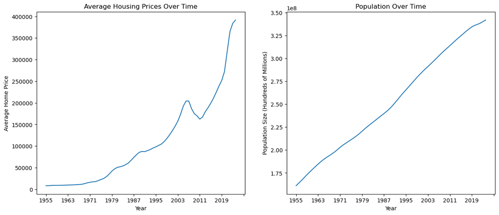

```python
graph_to_show_correletion('Average Housing Prices Over Time', 'Population Over Time', 'Avg_Home_Price', 'Population', 'Average Home Price', 'Population Size (Hundreds of Millions)')
```

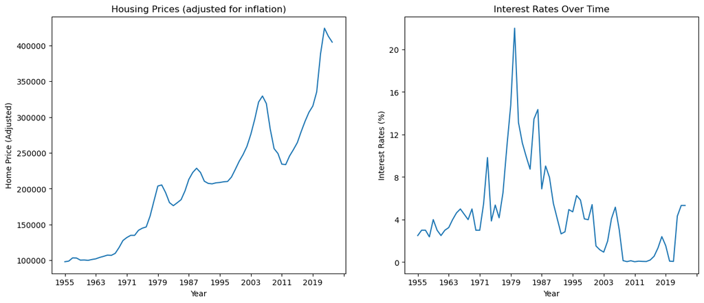

```python
graph_to_show_correletion('Housing Prices (adjusted for inflation)', 'Interest Rates Over Time', 'Inflation_Adjusted_Price', 'Interest_Rate', 'Home Price (Adjusted)', 'Interest Rates (%)')
```

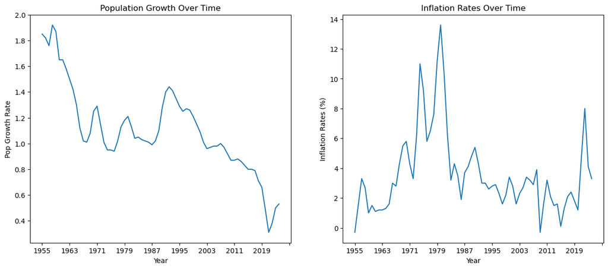

```python
graph_to_show_correletion('Population Growth Over Time', 'Inflation Rates Over Time', 'Growth_Rate', 'Avg_Inflation', 'Pop Growth Rate', 'Inflation Rates (%)')
```

### So what does this mean :

The 6 graphs above show how these different attributes have been affected overtime. This leads us to a conclusion on how they have affected the housing market :

```
- Population size : we See an Obvious Linear table which shows the population doubling since 1955. This shows that we could have a solid connection here between the price of houses and the population rise.

- House prices (Adjusted) : In this graph we see the effect of inflation on the market and it still rises. If Inflation was actually the cause of the housing prices increase, we should see that houses in the 50s (after being adjusted) also cost 400,000 dollars. Now obviously we don't see that and Instead we see the housing prices still increasing exponentially, meaning that inflation has a relatively low affect on the housing prices in the long run.

- Inflation Rates : While looking at the actual inflation data we can see that we had a high in 1979 (oil prices shot up) and since then a decrease and after that it has been up and down every few years. Because inflation rates are not exponentially increasing, we can draw the conclusion that it is not Inflation that has been shooting up the housing markets. This is also shown in our housing prices (adjusted) section.

- Interest Rates : The interest rate chart shows exactly what we explained earlier, that interest rates are used to reduce inflation. We can see in the chart that every time interest rates shoot up, inflation shoots way down. Due to the interests rates going up and down but the housing market barely being affected by it, we can conclude that this seems to affect the housing prices minorly or not at all.

- Population Growth Rate : I included this rate as I feel it is hard to see how the population is moving when dealing with such high numbers as we were. Therefore I included the growth rate as a different variable to showcase that the population growth is actually slowing down, an important thing to note as if the population growth is slowing down, so should the housing market prices if they are related to the population size, but instead of that again we are seeing an increase.
```

## Hypothesis Testing :

Now I will check the coefficients to see if these factors do In fact affect housing prices and if they do, we can run a linear regression model to look into the coefficients and see just how much they affect housing and if my own conclusions were correct.

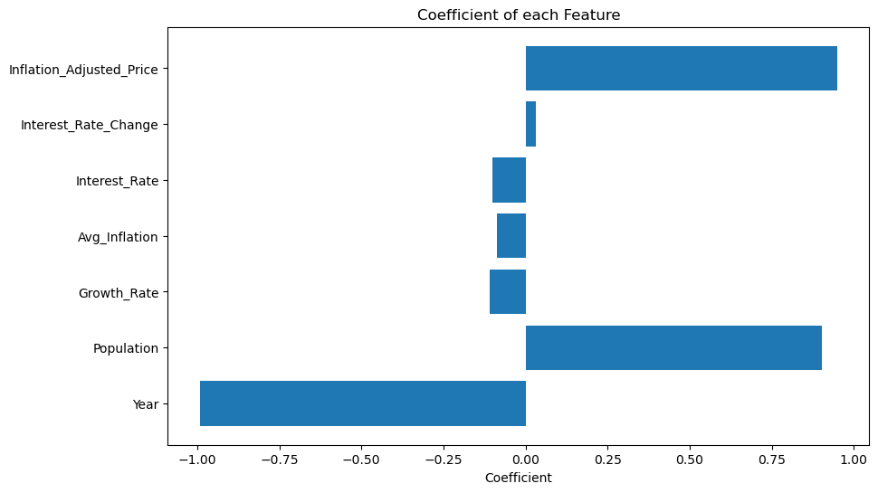

```python
from sklearn.linear_model import LinearRegression
from sklearn.model_selection import train_test_split
from sklearn import linear_model
import statsmodels.formula.api as smf
from sklearn.preprocessing import StandardScaler

X = combined_df.iloc[:, [col for col in range(combined_df.shape[1]) if col != 1]]  # All columns except the second
y = combined_df.iloc[:, 1]

scaler = StandardScaler()
X_scaled = scaler.fit_transform(X)
y_scaled = scaler.fit_transform(np.array(y).reshape(-1, 1)).flatten()
reg = LinearRegression().fit(X_scaled, y_scaled)

# set plot size and labels
plt.figure(figsize=(10, 6))
plt.title('Coefficient of each Feature')
plt.xlabel('Coefficient')

# create horizontal bar graph with features on the y-axis and the coefficient of each feature as the width
plt.barh(y = X.columns, width=reg.coef_)
plt.show()
```

To look deeper into this data and what may affect house growth in the future, we can look into a random forest feature importance.

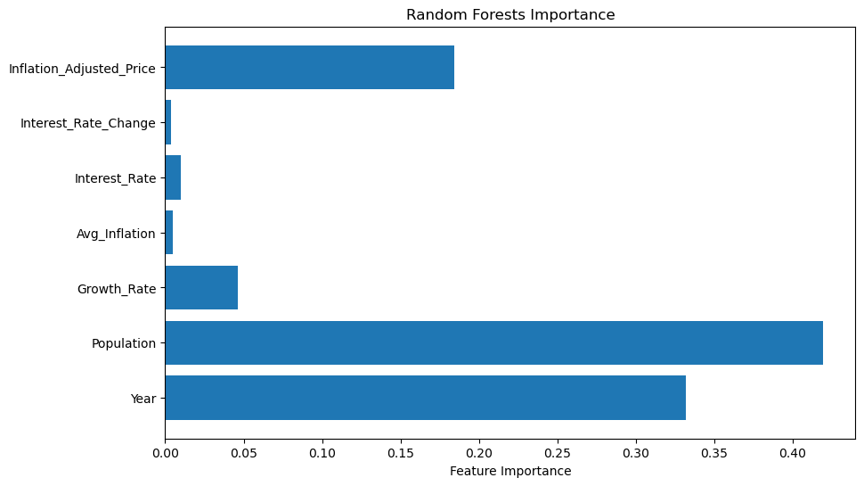

```python
from sklearn.ensemble import RandomForestRegressor
from sklearn import preprocessing

rfc = RandomForestRegressor(n_estimators=100, criterion="squared_error")
rfc.fit(X, y)

plt.figure(figsize=(10, 6))
plt.title('Random Forests Importance')
plt.xlabel('Feature Importance')

plt.barh(y=X.columns, width=rfc.feature_importances_)
plt.show()
```

## Future Predictions :

Looking at the data we have, and future calculations given to us by cbo.gov we can see that the population will grow on average by about 2 million people per year each year for the next 20 years according to the census (census.gov). With this being known and knowing the next few years, We can make a linear regression model that shows us where the housing prices may be in the next 10 years, making most students in the US today around 30-31, still half a decade earlier than when most people buy their first home according to the NAR ([CBSnews](https://www.cbsnews.com/news/first-time-homebuyer-age-realtor-data/)), and this number keeps increasing. By predicting these values this tutorial can serve as a sort of warning for people to try and buy houses sooner in life rather than later, as we have shown inflation does not even come close to keeping up with housing costs.

```
Year 2025: Predicted Avg Home Price: $258689.38
Year 2026: Predicted Avg Home Price: $262300.39
Year 2027: Predicted Avg Home Price: $265911.41
Year 2028: Predicted Avg Home Price: $269522.42
Year 2029: Predicted Avg Home Price: $273133.43
Year 2030: Predicted Avg Home Price: $276744.44
Year 2031: Predicted Avg Home Price: $280355.45
Year 2032: Predicted Avg Home Price: $283966.46
Year 2033: Predicted Avg Home Price: $287577.48
Year 2034: Predicted Avg Home Price: $291188.49
```

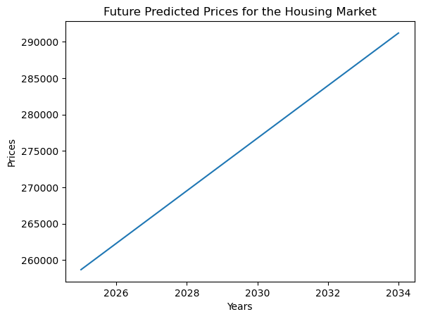

```python
X = combined_df[['Year', 'Population']]
y = combined_df['Avg_Home_Price']

# Split the data into training and testing sets (optional, for model evaluation)
X_train, X_test, y_train, y_test = train_test_split(X, y, test_size=0.2, random_state=42)

# Train the LinearRegression model
model = LinearRegression()
model.fit(X_train, y_train)

#generate future population and years
future_pop = []
current_pop = 341814420
future_years = np.arange(2025, 2035)

for i in range(10):
    current_pop = current_pop + 2000000
    future_pop.append(current_pop)

future_data = pd.DataFrame({
    'Year': future_years.flatten(),
    'Population': future_pop
})

# Predict future house prices
future_prices = model.predict(future_data)

# Print predicted house prices for future years
for year, price in zip(future_years, future_prices):
    print(f"Year {year}: Predicted Avg Home Price: ${price:.2f}")

plt.title('Future Predicted Prices for the Housing Market')
plt.xlabel('Years')
plt.ylabel('Prices')
plt.plot( future_years, future_prices)
plt.show()
```

Here we can see based off past values, when trying to predict future values we see the house prices are almost 100,000 less then what they are in real life. So what does this mean? it could mean teh predict function is off, but it could also mean that population and time do not affect house prices as much as the modern markets show. So this means there could possibly be a third party/feature that is pushing up the housing prices nation wide that we have not looked into. To look into this, we will first do a gradient descent algorithm given our same data based off of population growth. If the projections come out similarly, we may have to look into a third party and how they have a large affect on the housing market. As we already know, with population seemingly being the biggest contributer to housing price increase, it should also follow the growth of the population, but since the growth has been lowering every year seemingly since the 50s we should start to see a slow down of the market, but instead we are seeing it speed up.

```
Year 2025: Predicted Avg Home Price: $270564.14
Year 2026: Predicted Avg Home Price: $274050.69
Year 2027: Predicted Avg Home Price: $277537.24
Year 2028: Predicted Avg Home Price: $281023.78
Year 2029: Predicted Avg Home Price: $284510.33
Year 2030: Predicted Avg Home Price: $287996.88
Year 2031: Predicted Avg Home Price: $291483.43
Year 2032: Predicted Avg Home Price: $294969.97
Year 2033: Predicted Avg Home Price: $298456.52
Year 2034: Predicted Avg Home Price: $301943.07
```

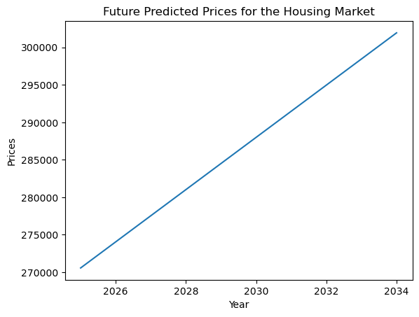

```python
X = combined_df[['Population']].values.astype(float)
y = combined_df['Avg_Home_Price'].values.astype(float)

mean_X = np.mean(X, axis=0)
std_X = np.std(X, axis=0)
X_normalized = (X - mean_X) / std_X

X_normalized = np.hstack([np.ones((X_normalized.shape[0], 1)), X_normalized])


T = 150
alpha = .0000001

def grad_descent(X,y,T,alpha):
    m, n = X.shape
    theta = np.zeros(n)
    f = np.zeros(T)
    for i in range(T):
        f[i] = 0.5*np.linalg.norm(X.dot(theta)-y)**2
        # g = np.transpose(X).dot(X.dot(theta)-y)
        g = X.T.dot(X.dot(theta) - y)
        theta -= (alpha*g)
    return(theta,f)

theta,loss = grad_descent(X_normalized,y,T,alpha)

future_years = np.arange(2025, 2035)
current_pop = 341814420
future_pop = [current_pop + i * 2000000 for i in range(1, 11)]

future_data = np.array(future_pop).reshape(-1, 1).astype(float)
future_data_normalized = (future_data - mean_X) / std_X
future_data_normalized = np.hstack([np.ones((future_data_normalized.shape[0], 1)), future_data_normalized])

future_prices = future_data_normalized @ theta

future_prices*=1000

for year, price in zip(future_years, future_prices):
    print(f"Year {year}: Predicted Avg Home Price: ${price:.2f}")

plt.title('Future Predicted Prices for the Housing Market')
plt.xlabel('Year')
plt.ylabel('Prices')
plt.plot(future_years, future_prices)
plt.show()
```

## Insight and Conclusion :

As we now see with gradient descent, we get the same output, a future housing price less than what it is based on right now. This was made using the most connected data we have and although inflation and interest may have a minor impact on the costs of houses in future years, it is mostly so small we can mitigate it and was proved to have very little effect by our graphs. So what does this mean? This means that there is definitely a third party getting involved and spiking up the housing market artificially, because the natural signs of a growing house market do not result in what we have today. After doing research through sources like Business Insider ([Black Rock's Involvement](https://www.businessinsider.com/blackrock-wall-street-investors-buy-homes-neighborhoods-single-family-rental-2021-6)) and CNBC ([CNBC on big Investment Corps](https://www.cnbc.com/2023/02/21/how-wall-street-bought-single-family-homes-and-put-them-up-for-rent.html)) which talk about how large investment firms since 2008 have been exponentially buying out single family homes at record speeds. They are doing this since after 2008, there were many cheap foreclosed homes, and many Americans who could not afford a home but needed a place to stay. These same people became the perfect renters, and so companies like Black Rock have started buying out entire neighborhoods.

#### So what does this mean? :

This means that average Americans are having a hard time finding houses for sale, as these large corporations are buying up all the possible houses and even if they do, these large firms outbid them, in some cases paying over 50% asking price to just acquire individual houses. Even if these corporations aren't buying up houses in your area, due to them buying out whole neighborhoods, it means people who do want to own have to move to other areas, this means the supply is being artificially shrunk by large corporations while the demand stays the same, inflating the prices of houses massively.

#### Is there anything that can be done? :

At the moment there doesn't seem to be much any single person can do, but that may change in the future with the growing frustration with these companies many are starting to call "monopolies" a term that has not been used since the great barons of old like Carnigie and Rockefeller. With this growing animosity, people are reaching out to their federal representatives about this issue and lawmakers have promised to start passing legislation to restrict and even take property back from these companies. The Wall Street Journal itself has an article based around this topic and how the congress and senate may make these large investment firms sell back their property to single families ([Wall Street Journal](https://www.wsj.com/real-estate/wall-street-has-spent-billions-buying-homes-a-crackdown-is-looming-f85ae5f6)). But I would not hedge your bets too soon, congress and senate have a long history of making promises but when money gets involved they flounder, this may even be taken further since in fact 3 of black rocks executives are on the president's Cabinet.

**So my advice :** buy land as soon as possible, because as far as we know these companies will not stop anytime soon by buying the middle class american out of their own homes. Real estate is the largest asset most americans will ever own, do not let these large companies take that away from you.